# Ontology_forpub

Eleanor Schille-Hudson

2025-07-30

# Participant Demographics

```
## ont_ctry_name
## Ecuador   Ghana    Peru      US
##      20      70      40      49
```

```
##              ont_version
## ont_ctry_name  1  2
##       Ecuador 10 10
##       Ghana   35 35
##       Peru    21 19
##       US      21 28
```

| ont_ctry_name | n | mean_age | med_age | sd_age | range_age |
| --- | --- | --- | --- | --- | --- |
| Ecuador | 20 | 27.50000 | 25.0 | 8.654175 | 18 - 50 |
| Ghana | 70 | 33.01429 | 27.5 | 13.261574 | 18 - 67 |
| Peru | 40 | 39.87500 | 37.5 | 13.305460 | 19 - 72 |
| US | 49 | 42.21277 | 35.0 | 16.268048 | 19 - 79 |

```
##              ont_sex
## ont_ctry_name  .  1  2
##       Ecuador  0  9 11
##       Ghana    0 32 38
##       Peru     0 25 15
##       US       1 26 22
```

```
##                                                       ont_ctry_name
## tolower(ont_ethn)                                      Ecuador Ghana Peru US
##   .                                                          0     1    0  2
##   a little bit of everything / caucasian/ puerto rican       0     0    0  1
##   ahanta                                                     0     1    0  0
##   akan- fante                                                0     1    0  0
##   american - hispanic / anglo                                0     0    0  1
##   asante/akan                                                0     1    0  0
##   asian                                                      0     0    0  1
##   asian + caucasian                                          0     0    0  1
##   black                                                      0     0    0  2
##   black + puerto rican                                       0     0    0  1
##   caucasian                                                  0     0    0 22
##   denkyiranyi (asante)                                       0     1    0  0
##   earth inn                                                  0     0    0  1
##   east indian                                                0     0    0  1
##   ekuapim                                                    0     1    0  0
##   fante                                                      0    49    0  0
##   fante (akromah)                                            0     1    0  0
##   fante (amosima)                                            0     1    0  0
##   fante (brenu)                                              0     1    0  0
##   fante (new ebu)                                            0     2    0  0
##   fante (otum in central region)                             0     1    0  0
##   fantenyi                                                   0     2    0  0
##   fanti                                                      0     1    0  0
##   fanti (cape-coast)                                         0     1    0  0
##   fanti (egyankwa)                                           0     1    0  0
##   fanti (yamoransa)                                          0     1    0  0
##   fanti(ahanta)                                              0     1    0  0
##   hispanic                                                   0     0    0  1
##   hispanic / caucasian                                       0     0    0  1
##   hispanic / native american                                 0     0    0  1
##   i am a fante.                                              0     1    0  0
##   irish                                                      0     0    0  1
##   irish/scottish/caucasian                                   0     0    0  1
##   italian                                                    0     0    0  1
##   italian/american                                           0     0    0  1
##   kichua                                                     1     0    0  0
##   mexican american                                           0     0    0  1
##   mexican/italian                                            0     0    0  1
##   mut                                                        0     0    0  1
##   n. european                                                0     0    0  1
##   northner                                                   0     1    0  0
##   persian                                                    0     0    0  1
##   portuguese                                                 0     0    0  1
##   salvadorian                                                0     0    0  1
##   scandanavian                                               0     0    0  1
##   scottish / english                                         0     0    0  1
##   shipibo                                                    0     0   40  0
##   waorani                                                   13     0    0  0
##   waorani and kichua                                         6     0    0  0
```

```
##                                              ont_ctry_name
## tolower(ont_hied)                             Ecuador Ghana Peru US
##   .                                                 1     1    0  1
##   0                                                 0     1    0  0
##   10th grade                                        2     0    0  0
##   11th grade                                        5     0    0  0
##   12th grade                                        9     0    0  0
##   1st yr college                                    0     0    0  1
##   3 yrs college                                     0     0    0  1
##   8th grade                                         1     0    0  0
##   9th grade                                         1     0    0  0
##   abakrampa senior high school                      0     1    0  0
##   abakrampa senior technical                        0     1    0  0
##   abk senior high                                   0     1    0  0
##   associate                                         0     0    0  1
##   associate's                                       0     0    0  2
##   ba                                                1     0    0  3
##   ba + teaching                                     0     0    0  1
##   bacelors                                          0     0    0  1
##   bachelor of science                               0     0    0  1
##   bachelor's                                        0     0    0  2
##   bachelors                                         0     0    0  3
##   brenu methodist school                            0     1    0  0
##   bs                                                0     0    0  3
##   college                                           0     0    0  3
##   college grad                                      0     0    0  1
##   did not complete junior high school               0     1    0  0
##   doctorate                                         0     0    0  1
##   elementary                                        0     1    0  0
##   form 4                                            0     3    0  0
##   form 4 (junior secondary school)                  0     1    0  0
##   ged                                               0     0    0  2
##   grad levels                                       0     0    0  1
##   grad school                                       0     0    0  1
##   graduate                                          0     0    0  1
##   graduated college                                 0     0    0  1
##   have not yet completed junior high school         0     1    0  0
##   high school                                       0     0    0  1
##   high school / some college                        0     0    0  1
##   high school some trade school                     0     0    0  1
```

[output cut: 25 more lines]

```
##   secondary school                                  0     1    0  0
##   self- hs                                          0     0    0  1
##   seminary school                                   0     1    0  0
##   senior high schol                                 0     1    0  0
##   senior high school                                0     5    0  0
##   senior high school graduate                       0     3    0  0
##   shs                                               0     3    0  0
##   shs- technical school                             0     1    0  0
##   sm college                                        0     0    0  1
##   some college                                      0     0    0  4
##   stan 7                                            0     1    0  0
##   takoradi senior secondary school                  0     1    0  0
##   uneducated                                        0     5    0  0
##   uneducated, did not attend school                 0     1    0  0
##   university of cape coast                          0     2    0  0
```

```
##              as.numeric(ont_imgd)
## ont_ctry_name -2 -1  0  1  2
##       Ecuador  6  1 10  2  0
##       Ghana    0  1  0 13 56
##       Peru     0  0  3  2 34
##       US      15  9  5  5 13
```

```
##                                                                    ont_ctry_name
## tolower(ont_chfq)                                                   Ecuador
##   .                                                                       0
##   0                                                                      15
##   1x/week                                                                 0
##   2 times a week.                                                         0
##   2 times in a week                                                       0
##   2x/week                                                                 0
##   3 times a month                                                         0
##   3 times a week                                                          0
##   3 times in a week                                                       0
##   3 to 4 times a year                                                     0
##   4 times a month                                                         0
##   4 times a week                                                          0
##   4 times in a week                                                       0
##   4,6, 8 times a month                                                    0
##   5 times a week                                                          0
##   5, 6 to 7 times a year                                                  0
##   7 times a week                                                          0
##   8 times a month                                                         0
##   a few times in a year                                                   0
##   a lot of times                                                          0
##   abundant life                                                           0
##   cathedral of faith, jubilee church on the hill, catholic churches       0
##   catholic                                                                0
##   every day                                                               0
##   every saturday                                                          0
##   every sunday                                                            0
##   every sunday, once a week                                               0
##   every week                                                              0
##   everyday                                                                0
##   everyday in new eden                                                    0
##   fante comment                                                           0
##   from time to time                                                       0
##   i don't usually go                                                      0
##   i don't usually go.                                                     0
##   i go to jesus divine temple. people popularly call it mountain.         0
##   infrequent                                                              3
##   infrequent but used to preach a few years ago                           1
##   it's been long                                                          0
```

[output cut: 182 more lines]

```
##   three times                                                        0
##   three times in a week.                                             0
##   thrice in a week                                                   0
##   twice a week                                                       0
##   twice in every week                                                0
##   twice in every week.                                               0
##   two times a week                                                   0
##   very often                                                         0
##   very often. every sunday                                           0
##   virtually every sunday                                             0
##   weekly                                                             2
##   weekly catholic                                                    1
##   when i am in school, i go to church every day                      0
##   yes, once a month                                                  0
##   you don't go at all.                                               0
```

```
##              as.numeric(ont_ses)
## ont_ctry_name -2 -1  0  1  2
##       Ecuador  0 10  9  1  0
##       Ghana    4 17 15 31  3
##       Peru    13  6 18  1  0
##       US       2 13 23  8  1
```

```
##              as.numeric(ont_affr)
## ont_ctry_name  0  1
##       Ecuador 20  0
##       Ghana   23 47
##       Peru    30  9
##       US       5 43
```

# Figure 1, Accompanying Analyses & Appendix C regression results

This way, a person who said they don’t know if it exists and a person who said it did or didn’t but said they were “not sure” will both get a score of 0. A person who is “very sure” it doesn’t exist will get a score of -3 and a person who is “very sure” it does exist will get a score of 3.

Graphing Figure 1

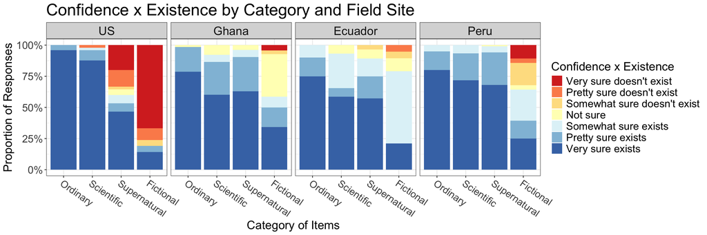

Models predicting confidence x existence scores by category with separate regressions for each country. The pairwise contrasts here showing ordinary vs. supernatural and scientific vs. supernatural are what make up Table 2. Full results are reported in Appendix C.

```
## Linear mixed model fit by REML. t-tests use Satterthwaite's method [
## lmerModLmerTest]
## Formula: conf_dir ~ question_type + (1 | ont_subj)
##    Data: filter(df_ext_usens_conf, ont_ctry_name == "US")
##
## REML criterion at convergence: 623.3
##
## Scaled residuals:
##      Min       1Q   Median       3Q      Max
## -2.90811 -0.26981  0.03141  0.27885  2.87739
##
## Random effects:
##  Groups   Name        Variance Std.Dev.
##  ont_subj (Intercept) 0.2108   0.4591
##  Residual             2.4359   1.5607
## Number of obs: 164, groups:  ont_subj, 49
##
## Fixed effects:
##                           Estimate Std. Error       df t value Pr(>|t|)
## (Intercept)                 2.9592     0.2324 157.8701  12.733  < 2e-16 ***
## question_typeScientific    -0.1837     0.3153 117.5352  -0.583    0.561
## question_typeSupernatural  -2.2480     0.3228 120.0307  -6.965 1.89e-10 ***
## question_typeFictional     -4.5905     0.4127 137.1724 -11.124  < 2e-16 ***
## ---
## Signif. codes:  0 '***' 0.001 '**' 0.01 '*' 0.05 '.' 0.1 ' ' 1
##
## Correlation of Fixed Effects:
##             (Intr) qstn_typSc qstn_typSp
## qstn_typScn -0.678
## qstn_typSpr -0.663  0.488
## qstn_typFct -0.518  0.382      0.376
```

```
##  contrast                  estimate    SE  df t.ratio p.value
##  Ordinary - Scientific        0.184 0.315 113   0.583  0.5614
##  Ordinary - Supernatural      2.248 0.323 116   6.962  <.0001
##  Ordinary - Fictional         4.590 0.415 134  11.069  <.0001
##  Scientific - Supernatural    2.064 0.323 116   6.393  <.0001
##  Scientific - Fictional       4.407 0.415 134  10.626  <.0001
##  Supernatural - Fictional     2.343 0.420 132   5.584  <.0001
##
## Degrees-of-freedom method: kenward-roger
```

```
## Linear mixed model fit by REML. t-tests use Satterthwaite's method [
## lmerModLmerTest]
## Formula: conf_dir ~ question_type + (1 | ont_subj)
##    Data: filter(df_ext_usens_conf, ont_ctry_name == "Ghana")
##
## REML criterion at convergence: 987.1
##
## Scaled residuals:
##     Min      1Q  Median      3Q     Max
## -4.3477 -0.4544  0.2218  0.5644  1.8879
##
## Random effects:
##  Groups   Name        Variance Std.Dev.
##  ont_subj (Intercept) 0.1388   0.3726
##  Residual             0.8719   0.9338
## Number of obs: 348, groups:  ont_subj, 70
##
## Fixed effects:
##                           Estimate Std. Error       df t value Pr(>|t|)
## (Intercept)                 2.7571     0.1202 319.5095  22.945   <2e-16 ***
## question_typeScientific    -0.3438     0.1452 279.7692  -2.368   0.0186 *
## question_typeSupernatural  -0.2845     0.1445 279.0482  -1.969   0.0500 *
## question_typeFictional     -1.4857     0.1578 274.6964  -9.413   <2e-16 ***
## ---
## Signif. codes:  0 '***' 0.001 '**' 0.01 '*' 0.05 '.' 0.1 ' ' 1
##
## Correlation of Fixed Effects:
##             (Intr) qstn_typSc qstn_typSp
## qstn_typScn -0.714
## qstn_typSpr -0.717  0.588
## qstn_typFct -0.657  0.544      0.546
```

```
##  contrast                  estimate    SE  df t.ratio p.value
##  Ordinary - Scientific       0.3438 0.145 280   2.368  0.0186
##  Ordinary - Supernatural     0.2845 0.145 279   1.968  0.0501
##  Ordinary - Fictional        1.4857 0.158 275   9.413  <.0001
##  Scientific - Supernatural  -0.0593 0.132 297  -0.450  0.6531
##  Scientific - Fictional      1.1419 0.145 280   7.865  <.0001
##  Supernatural - Fictional    1.2012 0.145 279   8.309  <.0001
##
## Degrees-of-freedom method: kenward-roger
```

```
## Linear mixed model fit by REML. t-tests use Satterthwaite's method [
## lmerModLmerTest]
## Formula: conf_dir ~ question_type + (1 | ont_subj)
##    Data: filter(df_ext_usens_conf, ont_ctry_name == "Ecuador")
##
## REML criterion at convergence: 283.7
##
## Scaled residuals:
##     Min      1Q  Median      3Q     Max
## -2.7683 -0.5352  0.2693  0.6102  2.0039
##
## Random effects:
##  Groups   Name        Variance Std.Dev.
##  ont_subj (Intercept) 0.2237   0.4730
##  Residual             0.9541   0.9768
## Number of obs: 96, groups:  ont_subj, 20
##
## Fixed effects:
##                           Estimate Std. Error      df t value Pr(>|t|)
## (Intercept)                 2.6500     0.2427 79.9977  10.920  < 2e-16 ***
## question_typeScientific    -0.5152     0.2855 74.0151  -1.804   0.0753 .
## question_typeSupernatural  -0.4465     0.2871 73.5156  -1.555   0.1242
## question_typeFictional     -1.5790     0.3134 72.8521  -5.038  3.3e-06 ***
## ---
## Signif. codes:  0 '***' 0.001 '**' 0.01 '*' 0.05 '.' 0.1 ' ' 1
##
## Correlation of Fixed Effects:
##             (Intr) qstn_typSc qstn_typSp
## qstn_typScn -0.688
## qstn_typSpr -0.685  0.574
## qstn_typFct -0.627  0.532      0.531
```

```
##  contrast                  estimate    SE   df t.ratio p.value
##  Ordinary - Scientific       0.5152 0.286 74.6   1.802  0.0756
##  Ordinary - Supernatural     0.4465 0.287 74.1   1.553  0.1246
##  Ordinary - Fictional        1.5790 0.314 73.5   5.036  <.0001
##  Scientific - Supernatural  -0.0687 0.266 78.5  -0.259  0.7965
##  Scientific - Fictional      1.0639 0.291 75.5   3.650  0.0005
##  Supernatural - Fictional    1.1325 0.292 74.3   3.878  0.0002
##
## Degrees-of-freedom method: kenward-roger
```

```
## Linear mixed model fit by REML. t-tests use Satterthwaite's method [
## lmerModLmerTest]
## Formula: conf_dir ~ question_type + (1 | ont_subj)
##    Data: filter(df_ext_usens_conf, ont_ctry_name == "Peru")
##
## REML criterion at convergence: 640.5
##
## Scaled residuals:
##     Min      1Q  Median      3Q     Max
## -4.2673 -0.5885  0.3191  0.4445  2.6123
##
## Random effects:
##  Groups   Name        Variance Std.Dev.
##  ont_subj (Intercept) 0.03865  0.1966
##  Residual             0.73159  0.8553
## Number of obs: 247, groups:  ont_subj, 40
##
## Fixed effects:
##                           Estimate Std. Error       df t value Pr(>|t|)
## (Intercept)                 2.7500     0.1388 239.5727  19.818   <2e-16 ***
## question_typeScientific    -0.1076     0.1748 208.1851  -0.615    0.539
## question_typeSupernatural  -0.1367     0.1563 205.0009  -0.874    0.383
## question_typeFictional     -2.0389     0.2115 213.8722  -9.639   <2e-16 ***
## ---
## Signif. codes:  0 '***' 0.001 '**' 0.01 '*' 0.05 '.' 0.1 ' ' 1
##
## Correlation of Fixed Effects:
##             (Intr) qstn_typSc qstn_typSp
## qstn_typScn -0.754
## qstn_typSpr -0.843  0.669
## qstn_typFct -0.623  0.497      0.553
```

```
##  contrast                  estimate    SE  df t.ratio p.value
##  Ordinary - Scientific       0.1076 0.175 208   0.615  0.5393
##  Ordinary - Supernatural     0.1367 0.156 205   0.874  0.3830
##  Ordinary - Fictional        2.0389 0.212 213   9.627  <.0001
##  Scientific - Supernatural   0.0291 0.136 210   0.214  0.8305
##  Scientific - Fictional      1.9313 0.197 213   9.821  <.0001
##  Supernatural - Fictional    1.9022 0.181 217  10.516  <.0001
##
## Degrees-of-freedom method: kenward-roger
```

Model predicting confidence x existence scores by category pooling across non-US countries. These results show that when you combine all non-US country responses together, the difference between ordinary and supernatural confidence ratings are significant.

```
## Linear mixed model fit by REML. t-tests use Satterthwaite's method [
## lmerModLmerTest]
## Formula: conf_dir ~ question_type + (1 | ont_ctry_name/ont_subj)
##    Data: filter(df_ext_usens_conf, ont_ctry_name != "US")
##
## REML criterion at convergence: 1924
##
## Scaled residuals:
##     Min      1Q  Median      3Q     Max
## -4.3864 -0.4471  0.2510  0.5377  2.2025
##
## Random effects:
##  Groups                 Name        Variance Std.Dev.
##  ont_subj:ont_ctry_name (Intercept) 0.113627 0.33709
##  ont_ctry_name          (Intercept) 0.003539 0.05949
##  Residual                           0.844475 0.91895
## Number of obs: 691, groups:  ont_subj:ont_ctry_name, 130; ont_ctry_name, 3
##
## Fixed effects:
##                            Estimate Std. Error        df t value Pr(>|t|)
## (Intercept)                 2.72942    0.09344   3.60849  29.210 2.03e-05 ***
## question_typeScientific    -0.29739    0.10470 563.96137  -2.840  0.00467 **
## question_typeSupernatural  -0.23851    0.09985 550.18991  -2.389  0.01724 *
## question_typeFictional     -1.63053    0.11738 560.02347 -13.891  < 2e-16 ***
## ---
## Signif. codes:  0 '***' 0.001 '**' 0.01 '*' 0.05 '.' 0.1 ' ' 1
##
## Correlation of Fixed Effects:
##             (Intr) qstn_typSc qstn_typSp
## qstn_typScn -0.664
## qstn_typSpr -0.698  0.618
## qstn_typFct -0.591  0.529      0.551
```

```
##  contrast                  estimate     SE  df t.ratio p.value
##  Ordinary - Scientific       0.2974 0.1050 569   2.840  0.0047
##  Ordinary - Supernatural     0.2385 0.1010 564   2.373  0.0180
##  Ordinary - Fictional        1.6305 0.1180 565  13.874  <.0001
##  Scientific - Supernatural  -0.0589 0.0903 590  -0.652  0.5144
##  Scientific - Fictional      1.3331 0.1080 573  12.292  <.0001
##  Supernatural - Fictional    1.3920 0.1060 561  13.190  <.0001
##
## Degrees-of-freedom method: kenward-roger
```

Model predicting confidence x existence scores by category, but only for highest contrast ordinary vs. supernatural items (coffee cups & tables vs. God & demons). These results show that these highest contrasts are significantly different in the US and Ghana, but not in Ecuador and Peru (in Ecuador, our smallest sample size, there are hints that this effect might be found in future similar studies). See Appendix A for full confidence and existence ratings broken down by item, version, and country.

```
## Linear mixed model fit by REML. t-tests use Satterthwaite's method [
## lmerModLmerTest]
## Formula: conf_dir ~ question_type + (1 | ont_subj)
##    Data: df_ext_usens_conf %>% filter(ont_ctry_name == "US", item_code %in%
##     c("mug", "tbl", "dem", "god"))
##
## REML criterion at convergence: 374.1
##
## Scaled residuals:
##      Min       1Q   Median       3Q      Max
## -2.09043  0.01938  0.02299  0.58511  1.29077
##
## Random effects:
##  Groups   Name        Variance Std.Dev.
##  ont_subj (Intercept) 0.008797 0.09379
##  Residual             3.134276 1.77039
## Number of obs: 94, groups:  ont_subj, 49
##
## Fixed effects:
##                           Estimate Std. Error      df t value Pr(>|t|)
## (Intercept)                 2.9592     0.2533 91.9994   11.68  < 2e-16 ***
## question_typeSupernatural  -2.2481     0.3656 48.9678   -6.15 1.38e-07 ***
## ---
## Signif. codes:  0 '***' 0.001 '**' 0.01 '*' 0.05 '.' 0.1 ' ' 1
##
## Correlation of Fixed Effects:
##             (Intr)
## qstn_typSpr -0.691
```

```
## Linear mixed model fit by REML. t-tests use Satterthwaite's method [
## lmerModLmerTest]
## Formula: conf_dir ~ question_type + (1 | ont_subj)
##    Data: df_ext_usens_conf %>% filter(ont_ctry_name == "Ghana", item_code %in%
##     c("mug", "tbl", "dem", "god"))
##
## REML criterion at convergence: 291.4
##
## Scaled residuals:
##     Min      1Q  Median      3Q     Max
## -3.3442 -0.1527 -0.0012  0.5653  1.7544
##
## Random effects:
##  Groups   Name        Variance Std.Dev.
##  ont_subj (Intercept) 0.2286   0.4781
##  Residual             0.2804   0.5296
## Number of obs: 140, groups:  ont_subj, 70
##
## Fixed effects:
##                            Estimate Std. Error        df t value Pr(>|t|)
## (Intercept)                 2.75714    0.08527 114.84211  32.333  < 2e-16 ***
## question_typeSupernatural  -0.30000    0.08951  69.00000  -3.352  0.00131 **
## ---
## Signif. codes:  0 '***' 0.001 '**' 0.01 '*' 0.05 '.' 0.1 ' ' 1
##
## Correlation of Fixed Effects:
##             (Intr)
## qstn_typSpr -0.525
```

```
## Linear mixed model fit by REML. t-tests use Satterthwaite's method [
## lmerModLmerTest]
## Formula: conf_dir ~ question_type + (1 | ont_subj)
##    Data:
## df_ext_usens_conf %>% filter(ont_ctry_name == "Ecuador", item_code %in%
##     c("mug", "tbl", "wen", "god"))
##
## REML criterion at convergence: 106.7
##
## Scaled residuals:
##     Min      1Q  Median      3Q     Max
## -3.0684 -0.3950  0.1042  0.7610  1.1422
##
## Random effects:
##  Groups   Name        Variance Std.Dev.
##  ont_subj (Intercept) 0.2511   0.5011
##  Residual             0.6754   0.8218
## Number of obs: 39, groups:  ont_subj, 20
##
## Fixed effects:
##                           Estimate Std. Error      df t value Pr(>|t|)
## (Intercept)                 2.6500     0.2152 34.6335  12.312 3.32e-14 ***
## question_typeSupernatural  -0.5397     0.2642 18.9685  -2.043   0.0552 .
## ---
## Signif. codes:  0 '***' 0.001 '**' 0.01 '*' 0.05 '.' 0.1 ' ' 1
##
## Correlation of Fixed Effects:
##             (Intr)
## qstn_typSpr -0.594
```

```
## Linear mixed model fit by REML. t-tests use Satterthwaite's method [
## lmerModLmerTest]
## Formula: conf_dir ~ question_type + (1 | ont_subj)
##    Data: df_ext_usens_conf %>% filter(ont_ctry_name == "Peru", item_code %in%
##     c("taz", "tbl", "oni", "god"))
##
## REML criterion at convergence: 125.4
##
## Scaled residuals:
##     Min      1Q  Median      3Q     Max
## -3.2867  0.4317  0.4317  0.4471  0.7038
##
## Random effects:
##  Groups   Name        Variance Std.Dev.
##  ont_subj (Intercept) 0.01877  0.1370
##  Residual             0.25314  0.5031
## Number of obs: 79, groups:  ont_subj, 40
##
## Fixed effects:
##                            Estimate Std. Error        df t value Pr(>|t|)
## (Intercept)                2.750000   0.082449 76.628610  33.354   <2e-16 ***
## question_typeSupernatural -0.007738   0.113272 38.128326  -0.068    0.946
## ---
## Signif. codes:  0 '***' 0.001 '**' 0.01 '*' 0.05 '.' 0.1 ' ' 1
##
## Correlation of Fixed Effects:
##             (Intr)
## qstn_typSpr -0.678
```

# Figure 2 & Accompanying Analyses

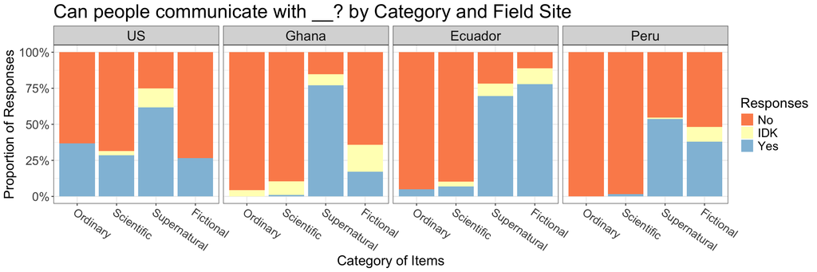

Models predicting “Can people communicate with X?” responses by category. The pairwise contrasts from these models are reported in the manuscript under the section “Additional Questions Reflect Differences in Epistemic Frames”

```
## Linear mixed model fit by REML. t-tests use Satterthwaite's method [
## lmerModLmerTest]
## Formula: response ~ category + (1 | ont_subj)
##    Data: filter(data_long_comm, ont_ctry_name == "US")
##
## REML criterion at convergence: 262
##
## Scaled residuals:
##     Min      1Q  Median      3Q     Max
## -1.9138 -0.6348 -0.1107  0.6635  2.5365
##
## Random effects:
##  Groups   Name        Variance Std.Dev.
##  ont_subj (Intercept) 0.08442  0.2905
##  Residual             0.12076  0.3475
## Number of obs: 244, groups:  ont_subj, 49
##
## Fixed effects:
##                       Estimate Std. Error        df t value Pr(>|t|)
## (Intercept)            0.36735    0.06471 142.69707   5.677  7.4e-08 ***
## categoryScientific    -0.03998    0.06510 193.23170  -0.614    0.540
## categoryFictional     -0.10204    0.07021 191.90328  -1.453    0.148
## categorySupernatural   0.28896    0.06399 193.08577   4.515  1.1e-05 ***
## ---
## Signif. codes:  0 '***' 0.001 '**' 0.01 '*' 0.05 '.' 0.1 ' ' 1
##
## Correlation of Fixed Effects:
##             (Intr) ctgrySc ctgryF
## ctgryScntfc -0.585
## catgryFctnl -0.542  0.539
## ctgrySprntr -0.595  0.581   0.549
```

```
##  contrast                  estimate     SE  df t.ratio p.value
##  Ordinary - Scientific       0.0400 0.0651 193   0.614  0.5399
##  Ordinary - Fictional        0.1020 0.0702 192   1.453  0.1477
##  Ordinary - Supernatural    -0.2890 0.0640 193  -4.515  <.0001
##  Scientific - Fictional      0.0621 0.0651 193   0.953  0.3417
##  Scientific - Supernatural  -0.3289 0.0591 198  -5.564  <.0001
##  Fictional - Supernatural   -0.3910 0.0640 193  -6.109  <.0001
##
## Degrees-of-freedom method: kenward-roger
```

```
## Linear mixed model fit by REML. t-tests use Satterthwaite's method [
## lmerModLmerTest]
## Formula: response ~ category + (1 | ont_subj)
##    Data: filter(data_long_comm, ont_ctry_name == "Ghana")
##
## REML criterion at convergence: 131.2
##
## Scaled residuals:
##      Min       1Q   Median       3Q      Max
## -2.94583 -0.33207 -0.08662  0.63525  2.97487
##
## Random effects:
##  Groups   Name        Variance Std.Dev.
##  ont_subj (Intercept) 0.006527 0.08079
##  Residual             0.075654 0.27505
## Number of obs: 350, groups:  ont_subj, 70
##
## Fixed effects:
##                       Estimate Std. Error        df t value Pr(>|t|)
## (Intercept)            0.02143    0.03426 337.26679   0.625    0.532
## categoryScientific     0.03737    0.04253 282.33502   0.879    0.380
## categoryFictional      0.24286    0.04649 277.00891   5.224 3.45e-07 ***
## categorySupernatural   0.78644    0.04253 282.33502  18.492  < 2e-16 ***
## ---
## Signif. codes:  0 '***' 0.001 '**' 0.01 '*' 0.05 '.' 0.1 ' ' 1
##
## Correlation of Fixed Effects:
##             (Intr) ctgrySc ctgryF
## ctgryScntfc -0.742
## catgryFctnl -0.678  0.547
## ctgrySprntr -0.742  0.593   0.547
```

```
##  contrast                  estimate     SE  df t.ratio p.value
##  Ordinary - Scientific      -0.0374 0.0425 282  -0.879  0.3804
##  Ordinary - Fictional       -0.2429 0.0465 277  -5.224  <.0001
##  Ordinary - Supernatural    -0.7864 0.0425 282 -18.486  <.0001
##  Scientific - Fictional     -0.2055 0.0425 282  -4.830  <.0001
##  Scientific - Supernatural  -0.7491 0.0384 302 -19.501  <.0001
##  Fictional - Supernatural   -0.5436 0.0425 282 -12.777  <.0001
##
## Degrees-of-freedom method: kenward-roger
```

```
## Linear mixed model fit by REML. t-tests use Satterthwaite's method [
## lmerModLmerTest]
## Formula: response ~ category + (1 | ont_subj)
##    Data: filter(data_long_comm, ont_ctry_name == "Ecuador")
##
## REML criterion at convergence: 61.5
##
## Scaled residuals:
##     Min      1Q  Median      3Q     Max
## -2.6608 -0.2785 -0.1655  0.5305  2.9256
##
## Random effects:
##  Groups   Name        Variance Std.Dev.
##  ont_subj (Intercept) 0.001555 0.03944
##  Residual             0.102169 0.31964
## Number of obs: 90, groups:  ont_subj, 20
##
## Fixed effects:
##                      Estimate Std. Error       df t value Pr(>|t|)
## (Intercept)           0.05000    0.07202 85.91024   0.694    0.489
## categoryScientific    0.03612    0.09295 71.44265   0.389    0.699
## categoryFictional     0.78346    0.10389 71.05523   7.541 1.18e-10 ***
## categorySupernatural  0.68932    0.09782 73.01647   7.047 8.52e-10 ***
## ---
## Signif. codes:  0 '***' 0.001 '**' 0.01 '*' 0.05 '.' 0.1 ' ' 1
##
## Correlation of Fixed Effects:
##             (Intr) ctgrySc ctgryF
## ctgryScntfc -0.763
## catgryFctnl -0.683  0.529
## ctgrySprntr -0.725  0.562   0.503
```

```
##  contrast                  estimate     SE   df t.ratio p.value
##  Ordinary - Scientific      -0.0361 0.0931 69.4  -0.388  0.6993
##  Ordinary - Fictional       -0.7835 0.1040 68.9  -7.533  <.0001
##  Ordinary - Supernatural    -0.6893 0.0981 71.1  -7.024  <.0001
##  Scientific - Fictional     -0.7473 0.0963 71.1  -7.759  <.0001
##  Scientific - Supernatural  -0.6532 0.0901 75.0  -7.248  <.0001
##  Fictional - Supernatural    0.0941 0.1010 72.1   0.931  0.3548
##
## Degrees-of-freedom method: kenward-roger
```

```
## Linear mixed model fit by REML. t-tests use Satterthwaite's method [
## lmerModLmerTest]
## Formula: response ~ category + (1 | ont_subj)
##    Data: filter(data_long_comm, ont_ctry_name == "Peru")
##
## REML criterion at convergence: 245.5
##
## Scaled residuals:
##      Min       1Q   Median       3Q      Max
## -1.45840 -1.11107 -0.01983  1.14905  2.42631
##
## Random effects:
##  Groups   Name        Variance Std.Dev.
##  ont_subj (Intercept) 0.003096 0.05564
##  Residual             0.147084 0.38352
## Number of obs: 248, groups:  ont_subj, 40
##
## Fixed effects:
##                        Estimate Std. Error         df t value Pr(>|t|)
## (Intercept)          -3.001e-16  6.127e-02  2.433e+02   0.000    1.000
## categoryScientific    1.601e-02  7.833e-02  2.090e+02   0.204    0.838
## categoryFictional     4.277e-01  9.368e-02  2.145e+02   4.565 8.39e-06 ***
## categorySupernatural  5.419e-01  7.010e-02  2.053e+02   7.731 4.68e-13 ***
## ---
## Signif. codes:  0 '***' 0.001 '**' 0.01 '*' 0.05 '.' 0.1 ' ' 1
##
## Correlation of Fixed Effects:
##             (Intr) ctgrySc ctgryF
## ctgryScntfc -0.766
## catgryFctnl -0.641  0.502
## ctgrySprntr -0.856  0.670   0.560
```

```
##  contrast                  estimate     SE  df t.ratio p.value
##  Ordinary - Scientific       -0.016 0.0784 209  -0.204  0.8384
##  Ordinary - Fictional        -0.428 0.0938 215  -4.560  <.0001
##  Ordinary - Supernatural     -0.542 0.0701 206  -7.731  <.0001
##  Scientific - Fictional      -0.412 0.0870 215  -4.733  <.0001
##  Scientific - Supernatural   -0.526 0.0608 212  -8.644  <.0001
##  Fictional - Supernatural    -0.114 0.0797 218  -1.433  0.1533
##
## Degrees-of-freedom method: kenward-roger
```

# Figure 3 & Accompanying Analyses

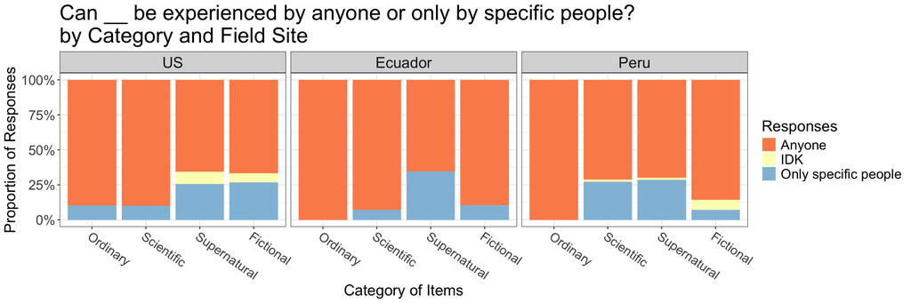

Models predicting “Can X be experienced by anyone or only by specific people?” responses by category. The pairwise contrasts from these models are reported in the manuscript under the section “Additional Questions Reflect Differences in Epistemic Frames”

```
## Linear mixed model fit by REML. t-tests use Satterthwaite's method [
## lmerModLmerTest]
## Formula: response ~ category + (1 | ont_subj)
##    Data: filter(data_long_spec, ont_ctry_name == "US")
##
## REML criterion at convergence: 220.1
##
## Scaled residuals:
##     Min      1Q  Median      3Q     Max
## -0.9216 -0.7635 -0.2711 -0.2271  2.4120
##
## Random effects:
##  Groups   Name        Variance Std.Dev.
##  ont_subj (Intercept) 0.002358 0.04856
##  Residual             0.139782 0.37387
## Number of obs: 234, groups:  ont_subj, 49
##
## Fixed effects:
##                        Estimate Std. Error         df t value Pr(>|t|)
## (Intercept)            0.102041   0.053859 229.724066   1.895  0.05940 .
## categoryScientific    -0.002248   0.069678 189.097447  -0.032  0.97429
## categoryFictional      0.197425   0.077221 187.294488   2.557  0.01136 *
## categorySupernatural   0.197507   0.069704 192.401201   2.834  0.00509 **
## ---
## Signif. codes:  0 '***' 0.001 '**' 0.01 '*' 0.05 '.' 0.1 ' ' 1
##
## Correlation of Fixed Effects:
##             (Intr) ctgrySc ctgryF
## ctgryScntfc -0.760
## catgryFctnl -0.686  0.530
## ctgrySprntr -0.760  0.586   0.531
```

```
##  contrast                   estimate     SE  df t.ratio p.value
##  Ordinary - Scientific      2.25e-03 0.0697 188   0.032  0.9743
##  Ordinary - Fictional      -1.97e-01 0.0772 186  -2.556  0.0114
##  Ordinary - Supernatural   -1.98e-01 0.0698 191  -2.831  0.0051
##  Scientific - Fictional    -2.00e-01 0.0716 194  -2.788  0.0058
##  Scientific - Supernatural -2.00e-01 0.0636 210  -3.139  0.0019
##  Fictional - Supernatural  -8.18e-05 0.0715 188  -0.001  0.9991
##
## Degrees-of-freedom method: kenward-roger
```

```
## Linear mixed model fit by REML. t-tests use Satterthwaite's method [
## lmerModLmerTest]
## Formula: response ~ category + (1 | ont_subj)
##    Data: filter(data_long_spec, ont_ctry_name == "Ecuador")
##
## REML criterion at convergence: 66.1
##
## Scaled residuals:
##      Min       1Q   Median       3Q      Max
## -1.17331 -0.34012 -0.19720 -0.01107  2.76448
##
## Random effects:
##  Groups   Name        Variance Std.Dev.
##  ont_subj (Intercept) 0.003315 0.05757
##  Residual             0.103822 0.32221
## Number of obs: 93, groups:  ont_subj, 20
##
## Fixed effects:
##                       Estimate Std. Error        df t value Pr(>|t|)
## (Intercept)          4.938e-17  7.319e-02 8.861e+01   0.000 1.000000
## categoryScientific   7.054e-02  9.447e-02 7.282e+01   0.747 0.457679
## categoryFictional    1.060e-01  1.033e-01 7.081e+01   1.027 0.308029
## categorySupernatural 3.470e-01  9.597e-02 7.287e+01   3.615 0.000549 ***
## ---
## Signif. codes:  0 '***' 0.001 '**' 0.01 '*' 0.05 '.' 0.1 ' ' 1
##
## Correlation of Fixed Effects:
##             (Intr) ctgrySc ctgryF
## ctgryScntfc -0.751
## catgryFctnl -0.687  0.532
## ctgrySprntr -0.739  0.571   0.524
```

```
##  contrast                  estimate     SE   df t.ratio p.value
##  Ordinary - Scientific      -0.0705 0.0947 72.9  -0.745  0.4587
##  Ordinary - Fictional       -0.1060 0.1030 70.9  -1.026  0.3083
##  Ordinary - Supernatural    -0.3470 0.0962 72.9  -3.606  0.0006
##  Scientific - Fictional     -0.0355 0.0963 74.2  -0.368  0.7136
##  Scientific - Supernatural  -0.2764 0.0891 80.2  -3.103  0.0026
##  Fictional - Supernatural   -0.2409 0.0977 73.2  -2.467  0.0160
##
## Degrees-of-freedom method: kenward-roger
```

```
## Linear mixed model fit by REML. t-tests use Satterthwaite's method [
## lmerModLmerTest]
## Formula: response ~ category + (1 | ont_subj)
##    Data: filter(data_long_spec, ont_ctry_name == "Peru")
##
## REML criterion at convergence: 250.4
##
## Scaled residuals:
##      Min       1Q   Median       3Q      Max
## -0.79931 -0.72533 -0.66887  0.03252  2.27273
##
## Random effects:
##  Groups   Name        Variance Std.Dev.
##  ont_subj (Intercept) 0.001803 0.04247
##  Residual             0.154486 0.39305
## Number of obs: 243, groups:  ont_subj, 40
##
## Fixed effects:
##                       Estimate Std. Error        df t value Pr(>|t|)
## (Intercept)          8.852e-17  6.251e-02 2.388e+02   0.000 1.000000
## categoryScientific   2.796e-01  8.054e-02 2.062e+02   3.471 0.000631 ***
## categoryFictional    1.064e-01  9.694e-02 2.116e+02   1.098 0.273642
## categorySupernatural 2.931e-01  7.207e-02 2.017e+02   4.066 6.85e-05 ***
## ---
## Signif. codes:  0 '***' 0.001 '**' 0.01 '*' 0.05 '.' 0.1 ' ' 1
##
## Correlation of Fixed Effects:
##             (Intr) ctgrySc ctgryF
## ctgryScntfc -0.767
## catgryFctnl -0.637  0.495
## ctgrySprntr -0.857  0.665   0.553
```

```
##  contrast                  estimate     SE  df t.ratio p.value
##  Ordinary - Scientific      -0.2796 0.0806 206  -3.469  0.0006
##  Ordinary - Fictional       -0.1064 0.0971 211  -1.096  0.2743
##  Ordinary - Supernatural    -0.2931 0.0721 201  -4.066  0.0001
##  Scientific - Fictional      0.1732 0.0904 212   1.915  0.0568
##  Scientific - Supernatural  -0.0135 0.0629 208  -0.214  0.8304
##  Fictional - Supernatural   -0.1867 0.0830 215  -2.248  0.0256
##
## Degrees-of-freedom method: kenward-roger
```

# Figure 4

Can __ be sensed? This combines across all sensory questions for each item. The items differed from country to country and version to version. But almost all contain the questions: see, hear, smell, touch, feel. Many but not all also had a taste question.

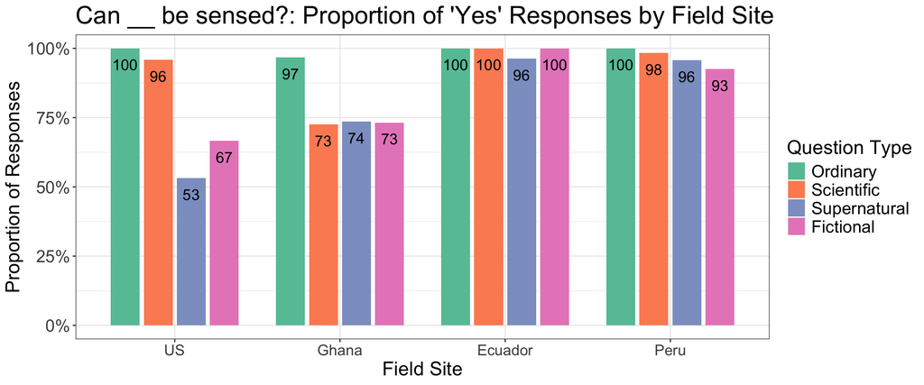

# Figure 5

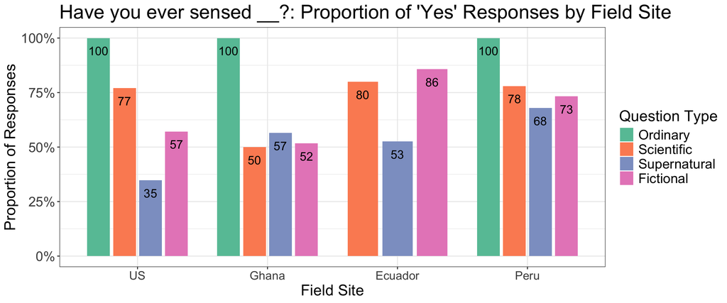

# Table 3 & Accompanying Analyses

Models predicting confidence x existence scores with consensus and sensory experience scores. The results are reported in Table 3 in the manuscript

```
## Linear mixed model fit by REML. t-tests use Satterthwaite's method [
## lmerModLmerTest]
## Formula:
## conf_dir ~ consensus_excl_self + usens_response + (1 | ont_ctry_name/ont_subj)
##    Data: df_ext_usens_conf
##
## REML criterion at convergence: 2134.2
##
## Scaled residuals:
##     Min      1Q  Median      3Q     Max
## -4.2610 -0.4330  0.0861  0.3859  3.9757
##
## Random effects:
##  Groups                 Name        Variance Std.Dev.
##  ont_subj:ont_ctry_name (Intercept) 0.132745 0.36434
##  ont_ctry_name          (Intercept) 0.009728 0.09863
##  Residual                           1.040922 1.02026
## Number of obs: 714, groups:  ont_subj:ont_ctry_name, 177; ont_ctry_name, 4
##
## Fixed effects:
##                      Estimate Std. Error        df t value Pr(>|t|)
## (Intercept)          -2.92816    0.21417  76.07243 -13.672   <2e-16 ***
## consensus_excl_self   5.00615    0.22733 354.91570  22.022   <2e-16 ***
## usens_response        0.78817    0.09002 688.50272   8.756   <2e-16 ***
## ---
## Signif. codes:  0 '***' 0.001 '**' 0.01 '*' 0.05 '.' 0.1 ' ' 1
##
## Correlation of Fixed Effects:
##             (Intr) cnsn__
## cnsnss_xcl_ -0.900
## usens_rspns -0.099 -0.197
```

Regression Results: Effects of Consensus and Sensory Evidence on Confidence

| **Characteristic** | **Beta** | **95% CI** | **p-value** |
| --- | --- | --- | --- |
| (Intercept) | -2.9 | -3.4, -2.5 | <0.001 |
| consensus_excl_self | 5.0 | 4.6, 5.5 | <0.001 |
| usens_response | 0.79 | 0.61, 0.96 | <0.001 |

Abbreviation: CI = Confidence Interval

# ALTERNATE CODING & FIG 1 et al

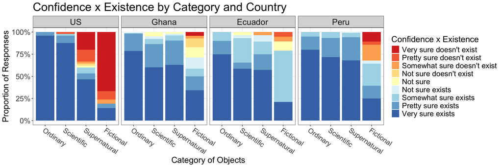

```
## Linear mixed model fit by REML. t-tests use Satterthwaite's method [
## lmerModLmerTest]
## Formula: conf_dir ~ question_type + (1 | ont_subj)
##    Data: filter(df_ext_usens_conf_ALT, ont_ctry_name == "US")
##
## REML criterion at convergence: 735.9
##
## Scaled residuals:
##      Min       1Q   Median       3Q      Max
## -3.05877 -0.27588  0.01684  0.27397  2.88053
##
## Random effects:
##  Groups   Name        Variance Std.Dev.
##  ont_subj (Intercept) 0.3683   0.6069
##  Residual             4.4209   2.1026
## Number of obs: 168, groups:  ont_subj, 49
##
## Fixed effects:
##                           Estimate Std. Error       df t value Pr(>|t|)
## (Intercept)                 3.9592     0.3126 161.8633  12.664  < 2e-16 ***
## question_typeScientific    -0.2245     0.4248 120.1173  -0.528    0.598
## question_typeSupernatural  -3.1020     0.4248 120.1173  -7.303 3.37e-11 ***
## question_typeFictional     -6.1828     0.5557 140.3890 -11.127  < 2e-16 ***
## ---
## Signif. codes:  0 '***' 0.001 '**' 0.01 '*' 0.05 '.' 0.1 ' ' 1
##
## Correlation of Fixed Effects:
##             (Intr) qstn_typSc qstn_typSp
## qstn_typScn -0.679
## qstn_typSpr -0.679  0.500
## qstn_typFct -0.519  0.382      0.382
```

```
##  contrast                  estimate    SE  df t.ratio p.value
##  Ordinary - Scientific        0.224 0.425 117   0.528  0.5982
##  Ordinary - Supernatural      3.102 0.425 117   7.303  <.0001
##  Ordinary - Fictional         6.183 0.558 138  11.072  <.0001
##  Scientific - Supernatural    2.878 0.425 117   6.774  <.0001
##  Scientific - Fictional       5.958 0.558 138  10.670  <.0001
##  Supernatural - Fictional     3.081 0.558 138   5.517  <.0001
##
## Degrees-of-freedom method: kenward-roger
```

```
## Linear mixed model fit by REML. t-tests use Satterthwaite's method [
## lmerModLmerTest]
## Formula: conf_dir ~ question_type + (1 | ont_subj)
##    Data: filter(df_ext_usens_conf_ALT, ont_ctry_name == "Ghana")
##
## REML criterion at convergence: 1160.3
##
## Scaled residuals:
##     Min      1Q  Median      3Q     Max
## -4.5726 -0.3506  0.1818  0.4952  1.8554
##
## Random effects:
##  Groups   Name        Variance Std.Dev.
##  ont_subj (Intercept) 0.1846   0.4296
##  Residual             1.4565   1.2068
## Number of obs: 349, groups:  ont_subj, 70
##
## Fixed effects:
##                           Estimate Std. Error       df t value Pr(>|t|)
## (Intercept)                 3.7571     0.1531 328.0187  24.539   <2e-16 ***
## question_typeScientific    -0.4260     0.1871 280.4269  -2.277   0.0235 *
## question_typeSupernatural  -0.3013     0.1867 280.3591  -1.614   0.1078
## question_typeFictional     -1.9429     0.2040 275.6218  -9.524   <2e-16 ***
## ---
## Signif. codes:  0 '***' 0.001 '**' 0.01 '*' 0.05 '.' 0.1 ' ' 1
##
## Correlation of Fixed Effects:
##             (Intr) qstn_typSc qstn_typSp
## qstn_typScn -0.726
## qstn_typSpr -0.728  0.590
## qstn_typFct -0.666  0.545      0.546
```

```
##  contrast                  estimate    SE  df t.ratio p.value
##  Ordinary - Scientific        0.426 0.187 281   2.276  0.0236
##  Ordinary - Supernatural      0.301 0.187 281   1.613  0.1079
##  Ordinary - Fictional         1.943 0.204 276   9.524  <.0001
##  Scientific - Supernatural   -0.125 0.169 298  -0.736  0.4621
##  Scientific - Fictional       1.517 0.187 281   8.106  <.0001
##  Supernatural - Fictional     1.642 0.187 281   8.789  <.0001
##
## Degrees-of-freedom method: kenward-roger
```

```
## Linear mixed model fit by REML. t-tests use Satterthwaite's method [
## lmerModLmerTest]
## Formula: conf_dir ~ question_type + (1 | ont_subj)
##    Data: filter(df_ext_usens_conf_ALT, ont_ctry_name == "Ecuador")
##
## REML criterion at convergence: 324.8
##
## Scaled residuals:
##     Min      1Q  Median      3Q     Max
## -3.7139 -0.5337  0.2668  0.5260  1.7660
##
## Random effects:
##  Groups   Name        Variance Std.Dev.
##  ont_subj (Intercept) 0.17     0.4123
##  Residual             1.60     1.2649
## Number of obs: 96, groups:  ont_subj, 20
##
## Fixed effects:
##                           Estimate Std. Error      df t value Pr(>|t|)
## (Intercept)                 3.6500     0.2975 88.3018  12.270  < 2e-16 ***
## question_typeScientific    -0.5375     0.3690 73.8784  -1.457    0.149
## question_typeSupernatural  -0.5322     0.3713 73.2224  -1.434    0.156
## question_typeFictional     -1.9014     0.4056 72.2588  -4.688 1.27e-05 ***
## ---
## Signif. codes:  0 '***' 0.001 '**' 0.01 '*' 0.05 '.' 0.1 ' ' 1
##
## Correlation of Fixed Effects:
##             (Intr) qstn_typSc qstn_typSp
## qstn_typScn -0.729
## qstn_typSpr -0.724  0.579
## qstn_typFct -0.663  0.534      0.532
```

```
##  contrast                  estimate    SE   df t.ratio p.value
##  Ordinary - Scientific      0.53746 0.370 75.2   1.454  0.1501
##  Ordinary - Supernatural    0.53225 0.372 74.6   1.432  0.1564
##  Ordinary - Fictional       1.90136 0.406 73.7   4.685  <.0001
##  Scientific - Supernatural -0.00521 0.342 80.4  -0.015  0.9879
##  Scientific - Fictional     1.36390 0.376 76.3   3.624  0.0005
##  Supernatural - Fictional   1.36911 0.378 74.8   3.625  0.0005
##
## Degrees-of-freedom method: kenward-roger
```

```
## Linear mixed model fit by REML. t-tests use Satterthwaite's method [
## lmerModLmerTest]
## Formula: conf_dir ~ question_type + (1 | ont_subj)
##    Data: filter(df_ext_usens_conf_ALT, ont_ctry_name == "Peru")
##
## REML criterion at convergence: 793
##
## Scaled residuals:
##     Min      1Q  Median      3Q     Max
## -4.2876 -0.4473  0.2786  0.3683  2.6448
##
## Random effects:
##  Groups   Name        Variance Std.Dev.
##  ont_subj (Intercept) 0.04796  0.219
##  Residual             1.28285  1.133
## Number of obs: 253, groups:  ont_subj, 40
##
## Fixed effects:
##                           Estimate Std. Error       df t value Pr(>|t|)
## (Intercept)                 3.7500     0.1824 247.1351  20.559   <2e-16 ***
## question_typeScientific    -0.1663     0.2307 215.1638  -0.721    0.472
## question_typeSupernatural  -0.1667     0.2068 211.7962  -0.806    0.421
## question_typeFictional     -2.8167     0.2691 217.8182 -10.467   <2e-16 ***
## ---
## Signif. codes:  0 '***' 0.001 '**' 0.01 '*' 0.05 '.' 0.1 ' ' 1
##
## Correlation of Fixed Effects:
##             (Intr) qstn_typSc qstn_typSp
## qstn_typScn -0.762
## qstn_typSpr -0.850  0.672
## qstn_typFct -0.653  0.518      0.576
```

```
##  contrast                  estimate    SE  df t.ratio p.value
##  Ordinary - Scientific      0.16633 0.231 214   0.721  0.4719
##  Ordinary - Supernatural    0.16667 0.207 210   0.806  0.4212
##  Ordinary - Fictional       2.81673 0.269 217  10.459  <.0001
##  Scientific - Supernatural  0.00034 0.179 216   0.002  0.9985
##  Scientific - Fictional     2.65040 0.248 217  10.692  <.0001
##  Supernatural - Fictional   2.65006 0.226 219  11.718  <.0001
##
## Degrees-of-freedom method: kenward-roger
```

Model predicting confidence x existence scores by category pooling across non-US countries. These results show that when you combine all non-US country responses together, the difference between ordinary and supernatural confidence ratings are significant.

```
## Linear mixed model fit by REML. t-tests use Satterthwaite's method [
## lmerModLmerTest]
## Formula: conf_dir ~ question_type + (1 | ont_ctry_name/ont_subj)
##    Data: filter(df_ext_usens_conf_ALT, ont_ctry_name != "US")
##
## REML criterion at convergence: 2293.9
##
## Scaled residuals:
##     Min      1Q  Median      3Q     Max
## -4.5239 -0.3322  0.2444  0.4483  2.0520
##
## Random effects:
##  Groups                 Name        Variance Std.Dev.
##  ont_subj:ont_ctry_name (Intercept) 0.1228   0.3504
##  ont_ctry_name          (Intercept) 0.0000   0.0000
##  Residual                           1.4453   1.2022
## Number of obs: 698, groups:  ont_subj:ont_ctry_name, 130; ont_ctry_name, 3
##
## Fixed effects:
##                           Estimate Std. Error       df t value Pr(>|t|)
## (Intercept)                 3.7385     0.1098 674.2405  34.039  < 2e-16 ***
## question_typeScientific    -0.3647     0.1366 571.9140  -2.671  0.00779 **
## question_typeSupernatural  -0.2598     0.1302 578.2497  -1.996  0.04639 *
## question_typeFictional     -2.1671     0.1520 566.5738 -14.255  < 2e-16 ***
## ---
## Signif. codes:  0 '***' 0.001 '**' 0.01 '*' 0.05 '.' 0.1 ' ' 1
##
## Correlation of Fixed Effects:
##             (Intr) qstn_typSc qstn_typSp
## qstn_typScn -0.741
## qstn_typSpr -0.778  0.623
## qstn_typFct -0.666  0.536      0.561
## optimizer (nloptwrap) convergence code: 0 (OK)
## boundary (singular) fit: see help('isSingular')
```

```
##  contrast                  estimate    SE  df t.ratio p.value
##  Ordinary - Scientific        0.365 0.137 577   2.670  0.0078
##  Ordinary - Supernatural      0.260 0.132 561   1.968  0.0495
##  Ordinary - Fictional         2.167 0.152 572  14.240  <.0001
##  Scientific - Supernatural   -0.105 0.118 581  -0.889  0.3746
##  Scientific - Fictional       1.802 0.140 580  12.887  <.0001
##  Supernatural - Fictional     1.907 0.137 541  13.951  <.0001
##
## Degrees-of-freedom method: kenward-roger
```

Model predicting confidence x existence scores by category, but only for highest contrast ordinary vs. supernatural items (coffee cups & tables vs. God & demons). These results show that these highest contrasts are significantly different in the US and Ghana, but not in Ecuador and Peru (in Ecuador, our smallest sample size, there are hints that this effect might be found in future similar studies). See Appendix A for full confidence and existence ratings broken down by item, version, and country.

```
## Linear mixed model fit by REML. t-tests use Satterthwaite's method [
## lmerModLmerTest]
## Formula: conf_dir ~ question_type + (1 | ont_subj)
##    Data:
## df_ext_usens_conf_ALT %>% filter(ont_ctry_name == "US", item_code %in%
##     c("mug", "tbl", "dem", "god"))
##
## REML criterion at convergence: 446.7
##
## Scaled residuals:
##      Min       1Q   Median       3Q      Max
## -2.03793  0.01365  0.01586  0.47946  1.31969
##
## Random effects:
##  Groups   Name        Variance Std.Dev.
##  ont_subj (Intercept) 0.01493  0.1222
##  Residual             5.65089  2.3772
## Number of obs: 98, groups:  ont_subj, 49
##
## Fixed effects:
##                           Estimate Std. Error      df t value Pr(>|t|)
## (Intercept)                 3.9592     0.3400 95.9993  11.643  < 2e-16 ***
## question_typeSupernatural  -3.1020     0.4803 48.0380  -6.459 4.95e-08 ***
## ---
## Signif. codes:  0 '***' 0.001 '**' 0.01 '*' 0.05 '.' 0.1 ' ' 1
##
## Correlation of Fixed Effects:
##             (Intr)
## qstn_typSpr -0.706
```

```
## Linear mixed model fit by REML. t-tests use Satterthwaite's method [
## lmerModLmerTest]
## Formula: conf_dir ~ question_type + (1 | ont_subj)
##    Data:
## df_ext_usens_conf_ALT %>% filter(ont_ctry_name == "Ghana", item_code %in%
##     c("mug", "tbl", "dem", "god"))
##
## REML criterion at convergence: 314.8
##
## Scaled residuals:
##     Min      1Q  Median      3Q     Max
## -3.7306 -0.1313  0.0024  0.5628  1.5196
##
## Random effects:
##  Groups   Name        Variance Std.Dev.
##  ont_subj (Intercept) 0.2505   0.5005
##  Residual             0.3438   0.5863
## Number of obs: 140, groups:  ont_subj, 70
##
## Fixed effects:
##                            Estimate Std. Error        df t value Pr(>|t|)
## (Intercept)                 3.75714    0.09214 117.17884  40.776  < 2e-16 ***
## question_typeSupernatural  -0.32857    0.09911  69.00000  -3.315  0.00146 **
## ---
## Signif. codes:  0 '***' 0.001 '**' 0.01 '*' 0.05 '.' 0.1 ' ' 1
##
## Correlation of Fixed Effects:
##             (Intr)
## qstn_typSpr -0.538
```

```
## Linear mixed model fit by REML. t-tests use Satterthwaite's method [
## lmerModLmerTest]
## Formula: conf_dir ~ question_type + (1 | ont_subj)
##    Data: df_ext_usens_conf_ALT %>% filter(ont_ctry_name == "Ecuador",
##     item_code %in% c("mug", "tbl", "wen", "god"))
##
## REML criterion at convergence: 122
##
## Scaled residuals:
##     Min      1Q  Median      3Q     Max
## -4.0763 -0.2848  0.1576  0.7600  0.9070
##
## Random effects:
##  Groups   Name        Variance Std.Dev.
##  ont_subj (Intercept) 0.2116   0.460
##  Residual             1.1538   1.074
## Number of obs: 39, groups:  ont_subj, 20
##
## Fixed effects:
##                           Estimate Std. Error      df t value Pr(>|t|)
## (Intercept)                 3.6500     0.2613 36.1945  13.969 3.76e-16 ***
## question_typeSupernatural  -0.6471     0.3448 19.0832  -1.877   0.0759 .
## ---
## Signif. codes:  0 '***' 0.001 '**' 0.01 '*' 0.05 '.' 0.1 ' ' 1
##
## Correlation of Fixed Effects:
##             (Intr)
## qstn_typSpr -0.640
```

```
## Linear mixed model fit by REML. t-tests use Satterthwaite's method [
## lmerModLmerTest]
## Formula: conf_dir ~ question_type + (1 | ont_subj)
##    Data:
## df_ext_usens_conf_ALT %>% filter(ont_ctry_name == "Peru", item_code %in%
##     c("taz", "tbl", "oni", "god"))
##
## REML criterion at convergence: 163.7
##
## Scaled residuals:
##     Min      1Q  Median      3Q     Max
## -4.8913  0.2505  0.2505  0.4187  0.9844
##
## Random effects:
##  Groups   Name        Variance Std.Dev.
##  ont_subj (Intercept) 0.08974  0.2996
##  Residual             0.35385  0.5948
## Number of obs: 80, groups:  ont_subj, 40
##
## Fixed effects:
##                           Estimate Std. Error      df t value Pr(>|t|)
## (Intercept)                 3.7500     0.1053 74.9330  35.610   <2e-16 ***
## question_typeSupernatural  -0.1000     0.1330 39.0000  -0.752    0.457
## ---
## Signif. codes:  0 '***' 0.001 '**' 0.01 '*' 0.05 '.' 0.1 ' ' 1
##
## Correlation of Fixed Effects:
##             (Intr)
## qstn_typSpr -0.632
```

# Appendix A: Responses by object, version, and country

## Existence

### US

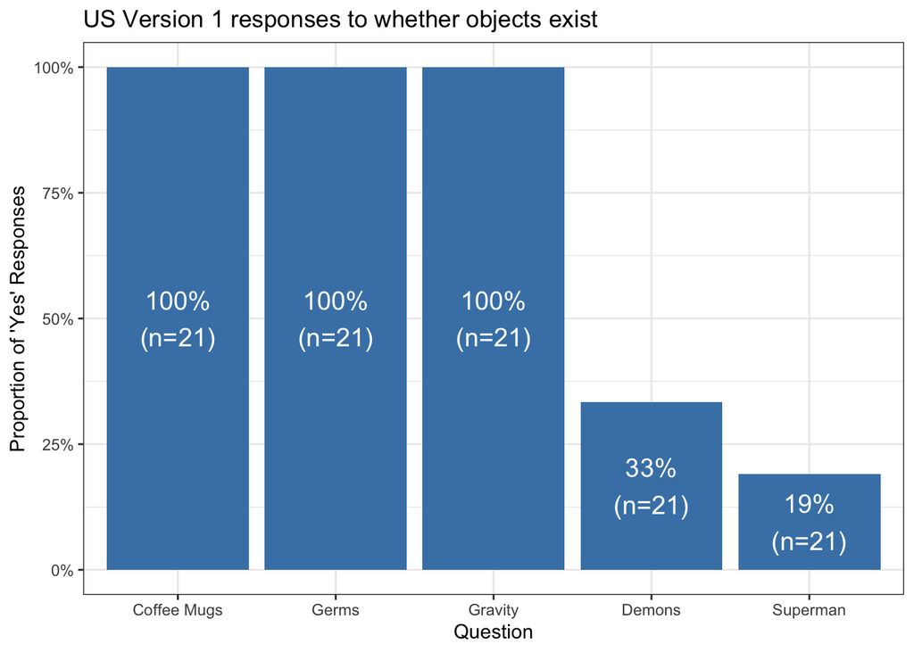

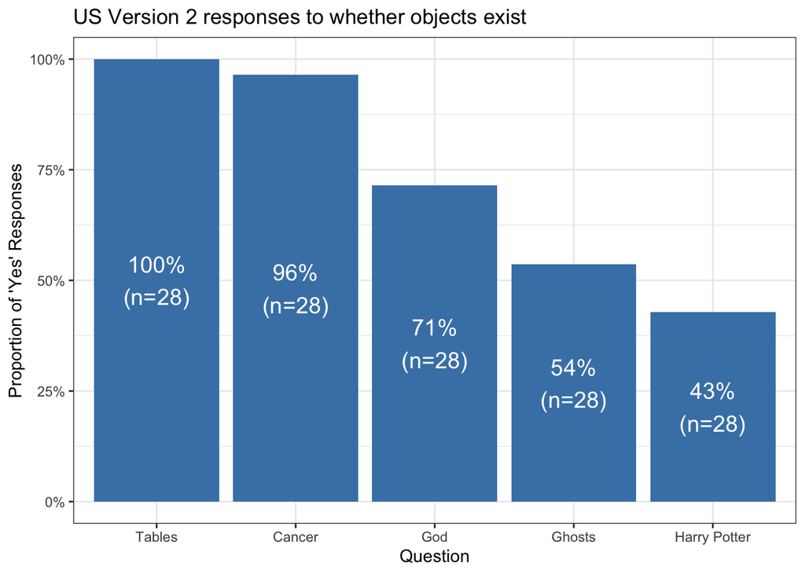

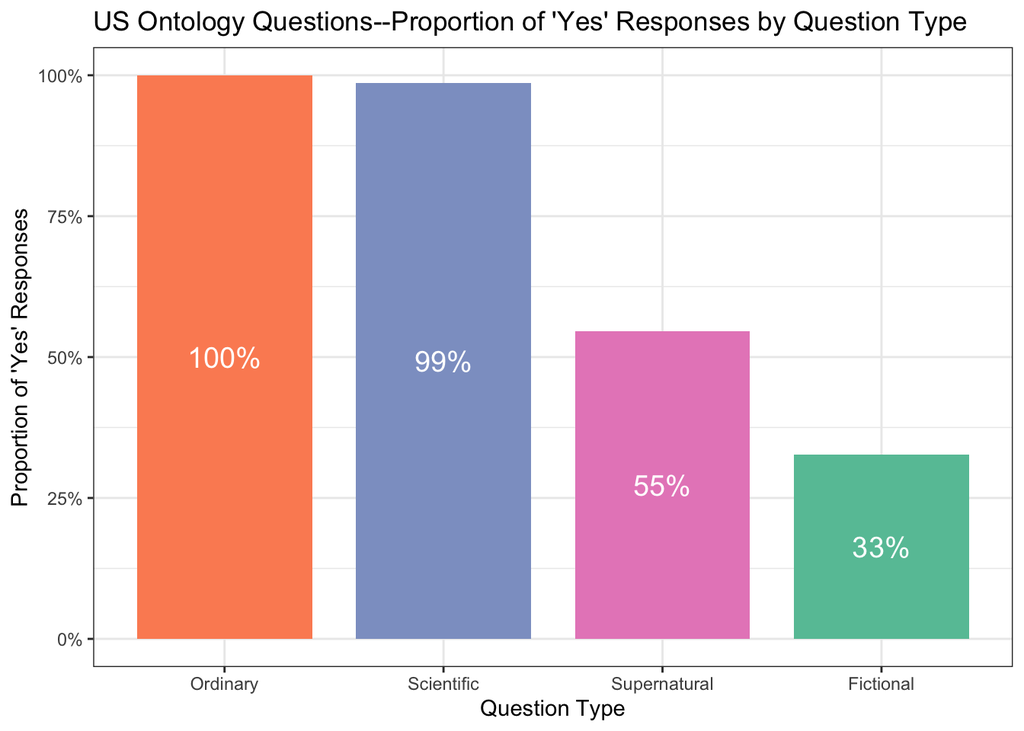

### Ghana

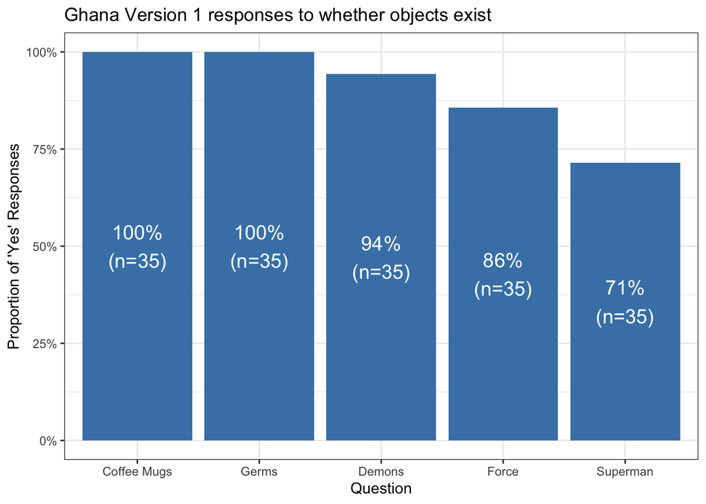

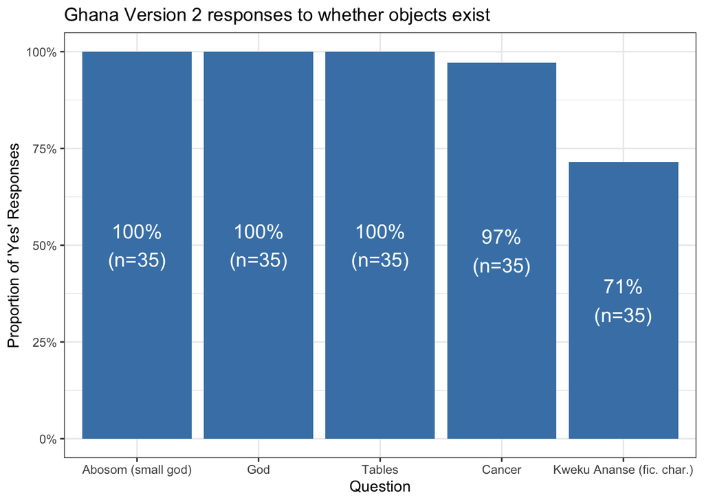

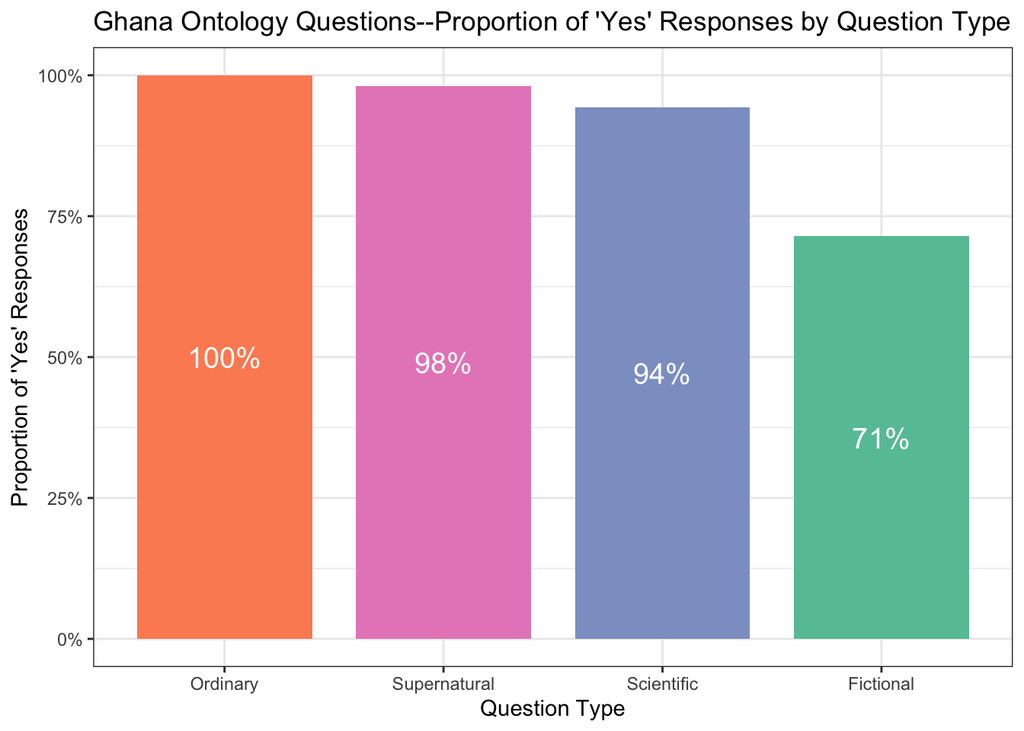

### Ecuador

[figure not shown]

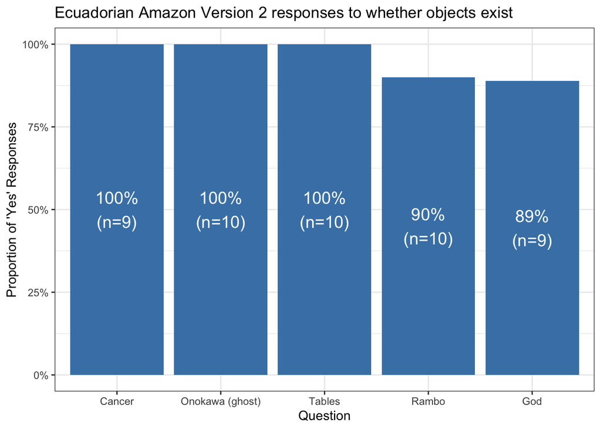

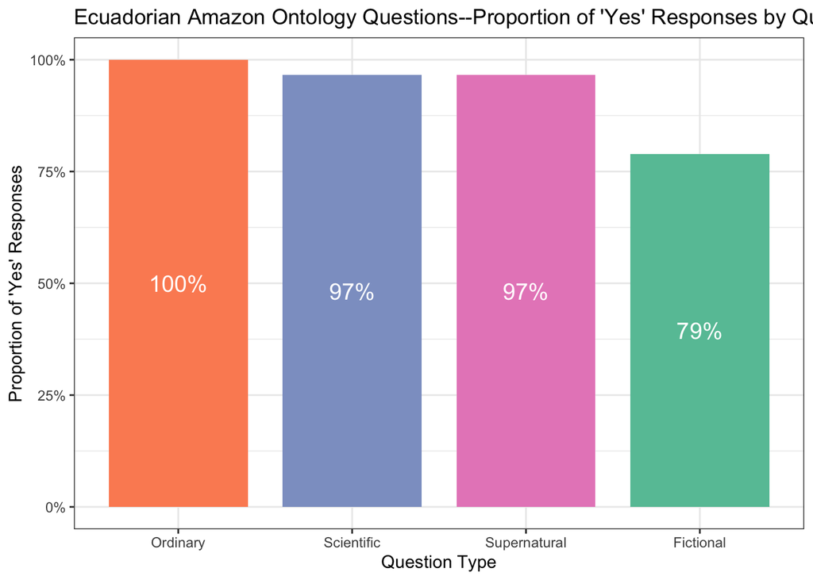

### Peru

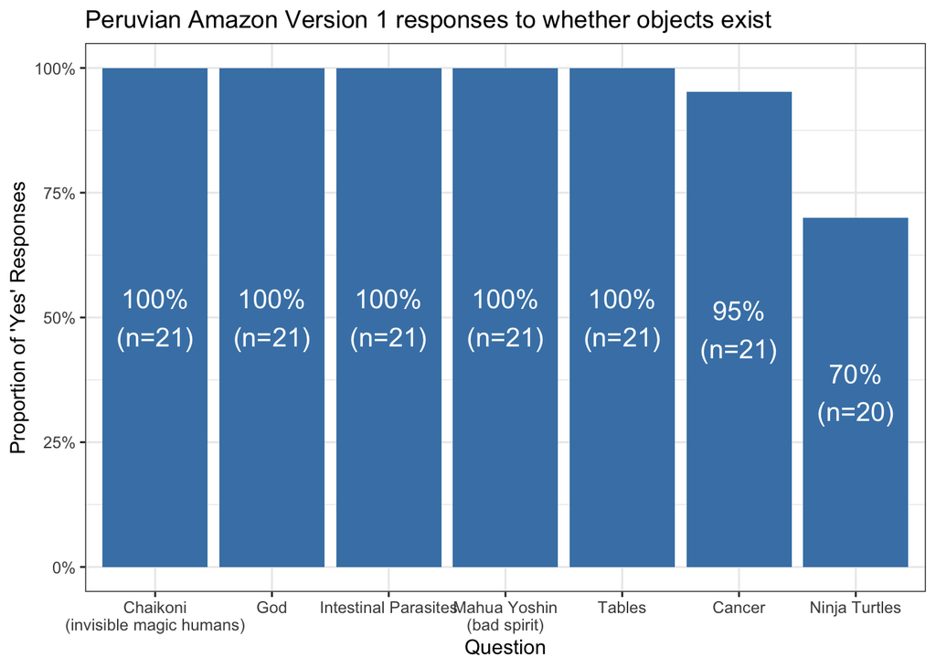

[figure not shown]

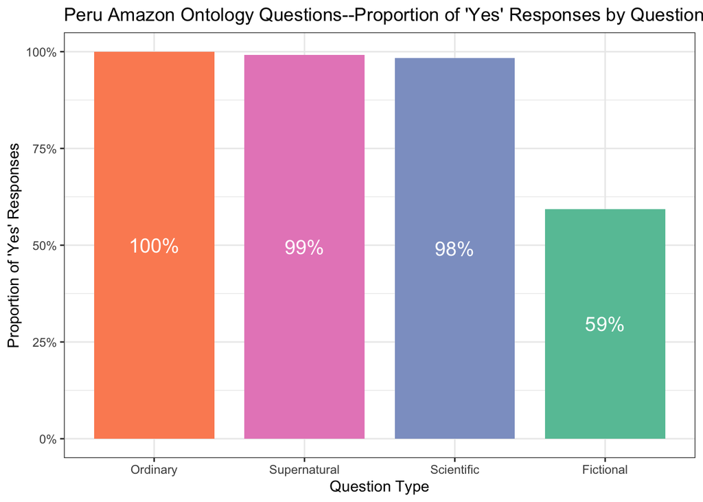

## Confidence

### US

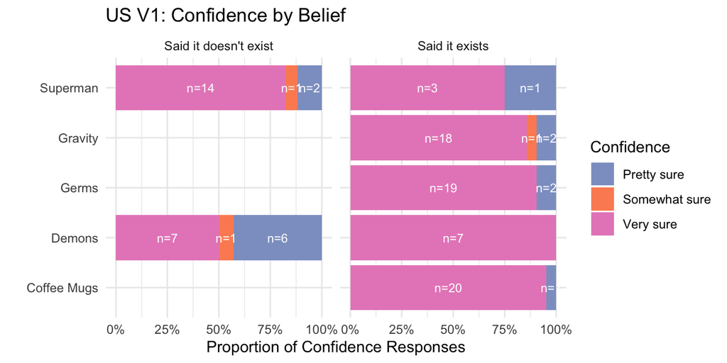

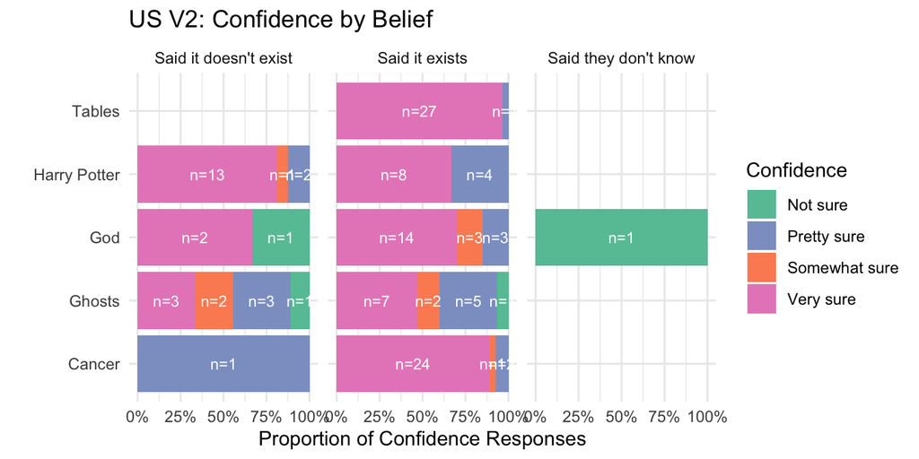

### Ghana

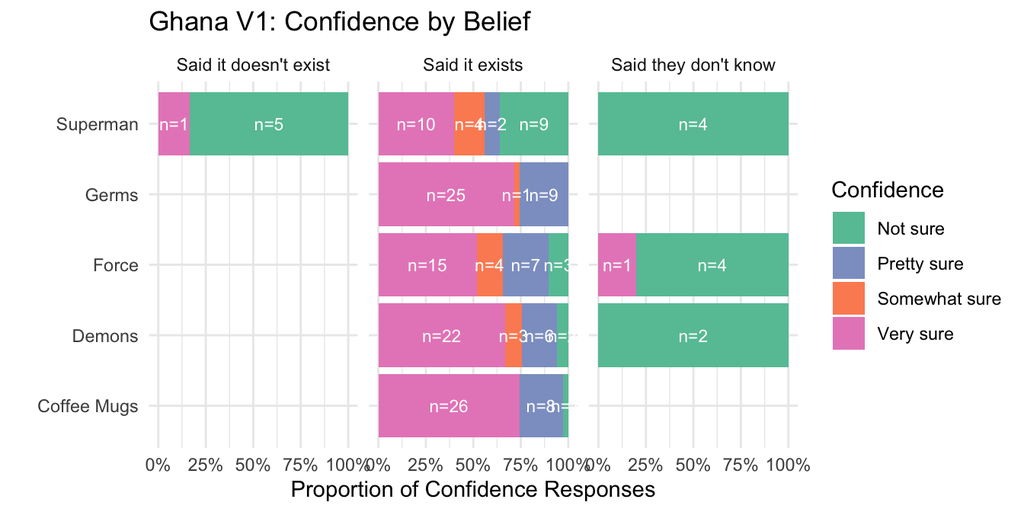

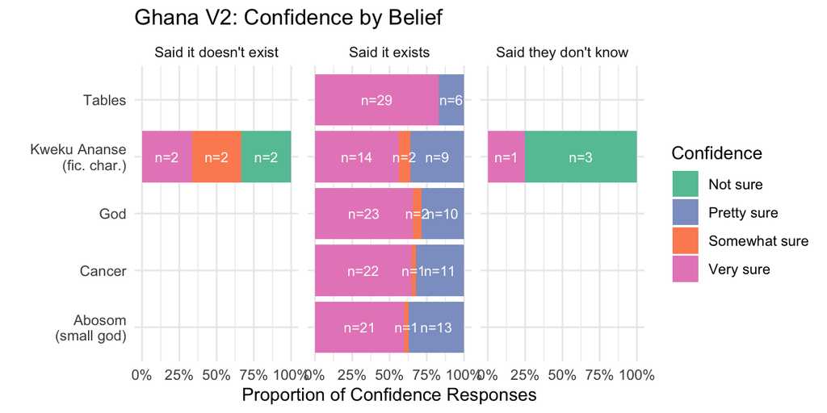

### Ecuador

[figure not shown]

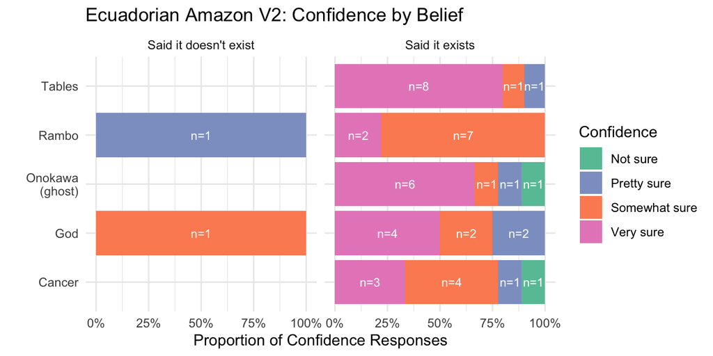

### Peru

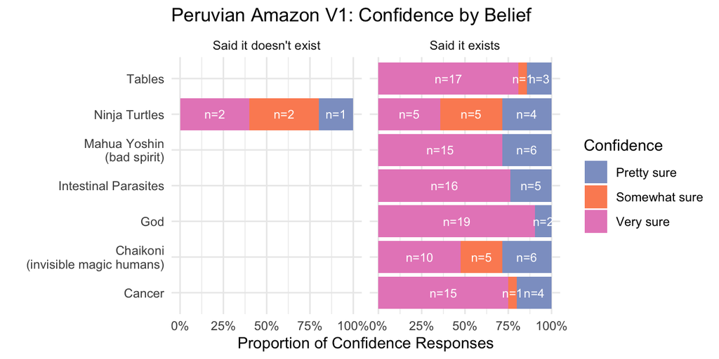

[figure not shown]

## Communication

### US

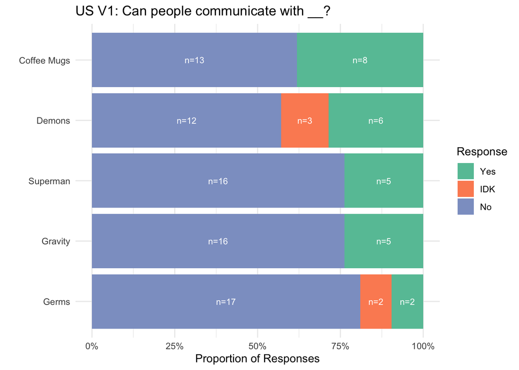

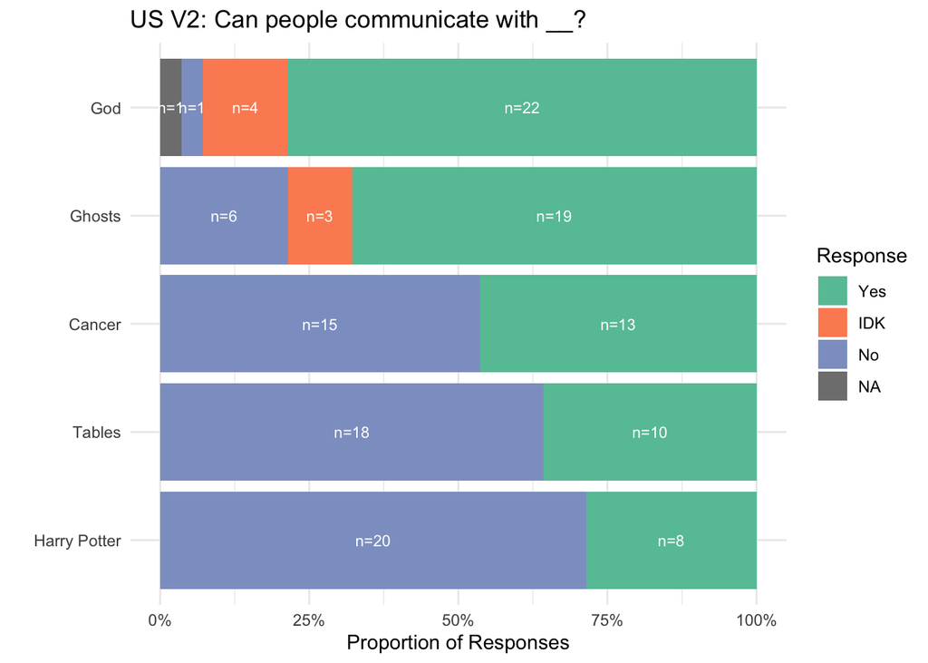

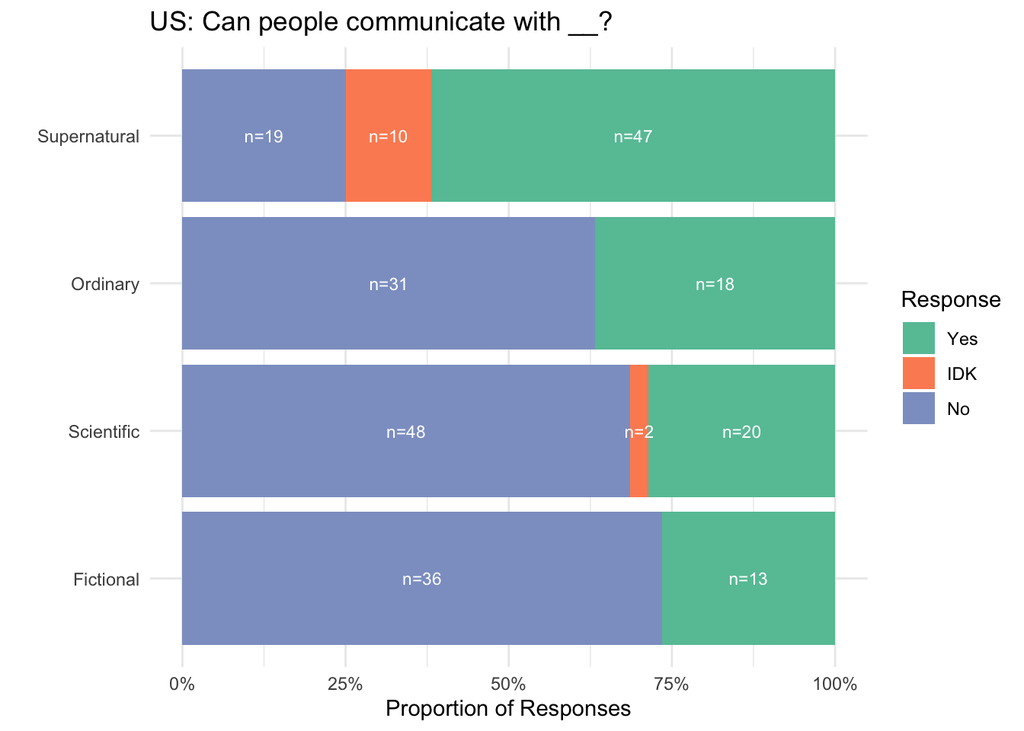

### Ghana

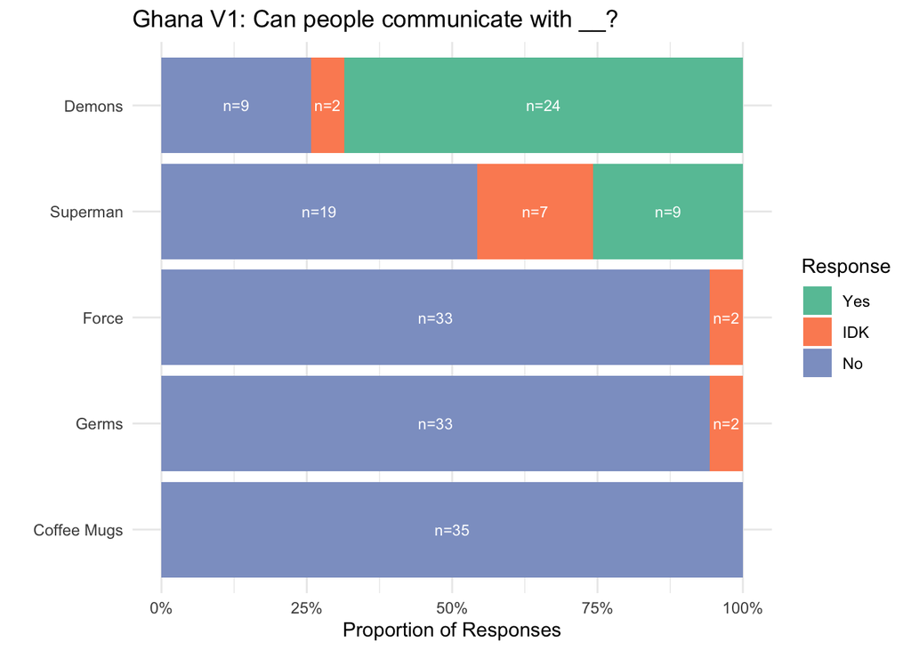

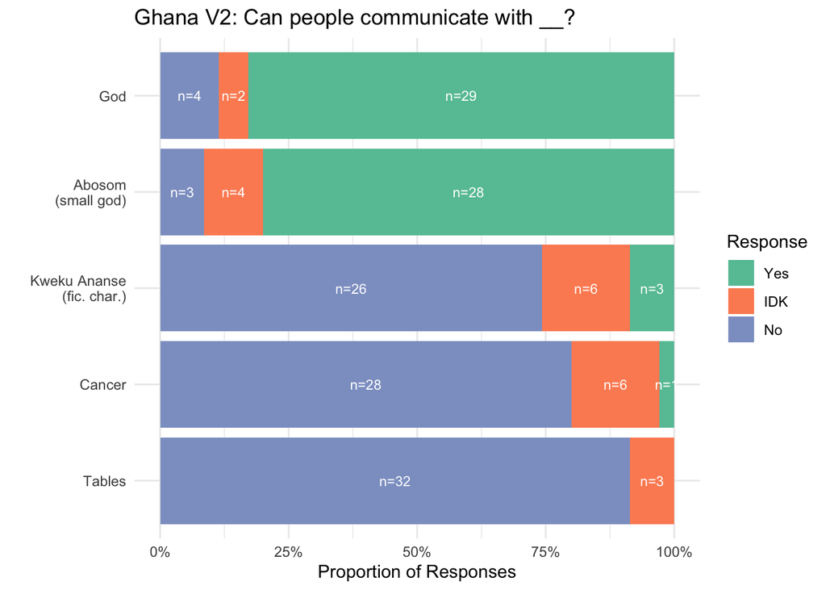

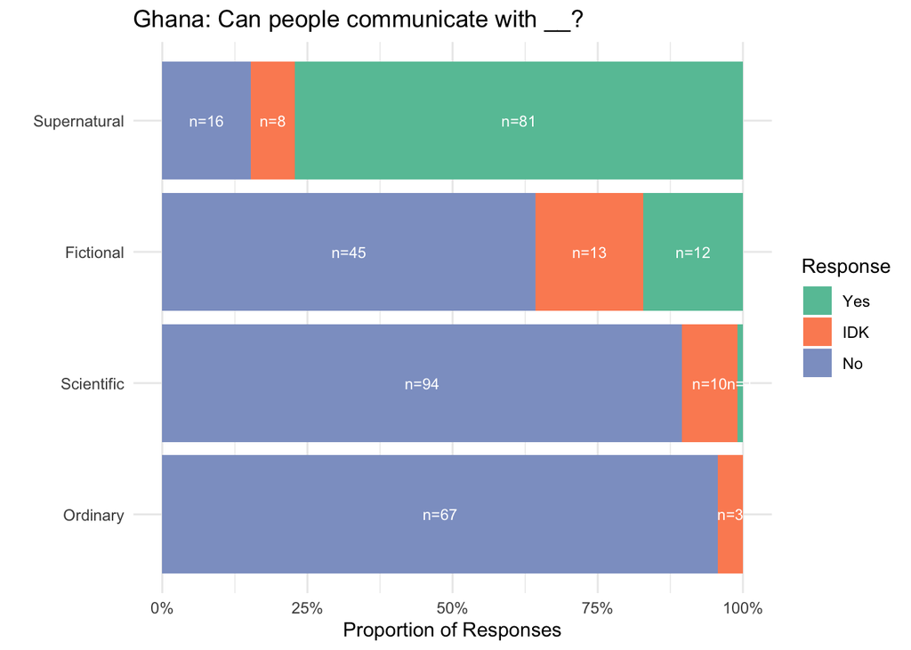